# R Notebook

```r
library(tidyverse)
library(janitor)
library(infer)
data(msleep)
```

```r
View(msleep)
```

Now we’ll visualise the distribution of the sleep_total values

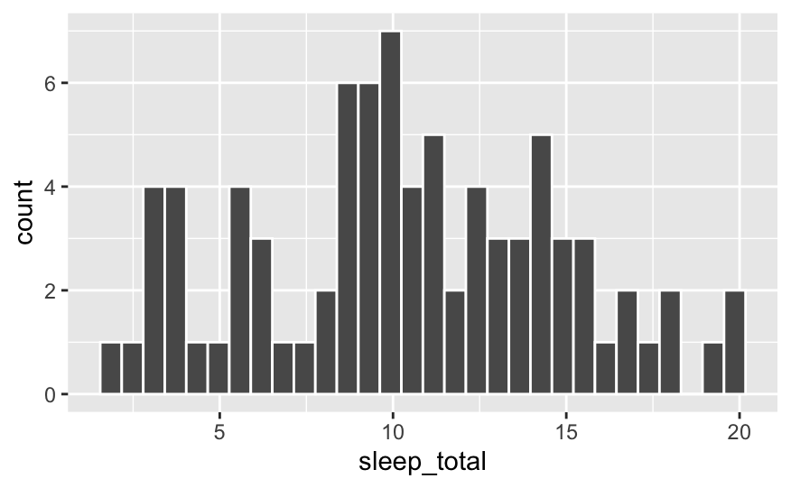

```r
msleep %>%
  ggplot(aes(x = sleep_total)) +
  geom_histogram(col = "white")
```

lets check for any specific outliers in a boxplot

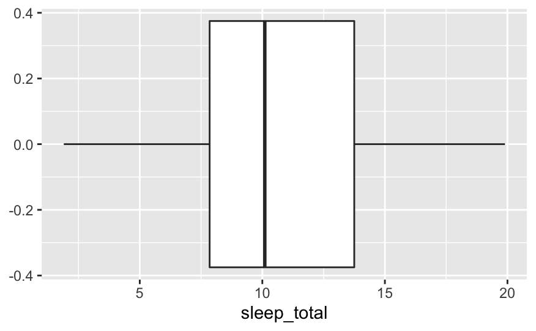

```r
msleep %>%
  ggplot(aes(y = sleep_total)) +
  geom_boxplot() +
  coord_flip()
```

The mean average_sleep for our imaginary Jabberwockies is 7. Now, we have taken this current sample of animals, and we want to know if the mean sleep_total for Jabberwockies differs significantly from the meean sleep_total of our animals data set?

First and most important task is to frame this question in terms of two competing hypotheses:

H0- the current mean Jabberwockies is the same as the mean sleep_total.

Ha- the current mean Jabberwockies is different as the mean sleep_total

We can write our two hypotheses more mathematically as:

H0: μsleep_total = 7 Ha: μsleep_total ≠ 7

Step 1 :let is first create an observed stat for our reference later

```r
observed_stat <- msleep %>%
  summarise(average_sleep = mean(sleep_total))

observed_stat
```

| average_sleep |
| --- |
| 10.43373 |

First let is now set up our alpha = 0.05

Next, we treat the situation specified by the null hypothesis as if it were true, and use this to generate a sampling distribution, which we call the null sampling distribution. We’ll bootstrap to do this in the normal way

Calculating the null sampling distribution

```r
null_distribution <- msleep %>%
  specify(response = sleep_total) %>%
  hypothesize(null = "point", mu = 7) %>%
  generate(reps = 10000, type = "bootstrap") %>%
  calculate(stat = "mean")
```

Now we can visualise the null distribution in the normal way

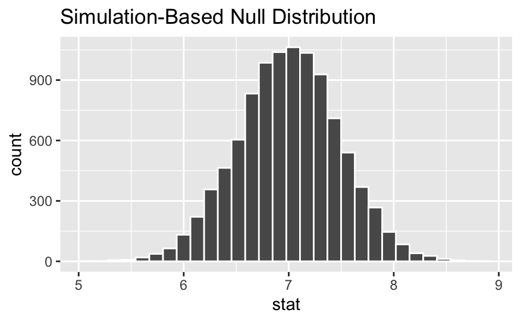

```r
null_distribution %>%
  visualise(bins = 30)
```

Let’s now plot this observed stats on the null distribution.

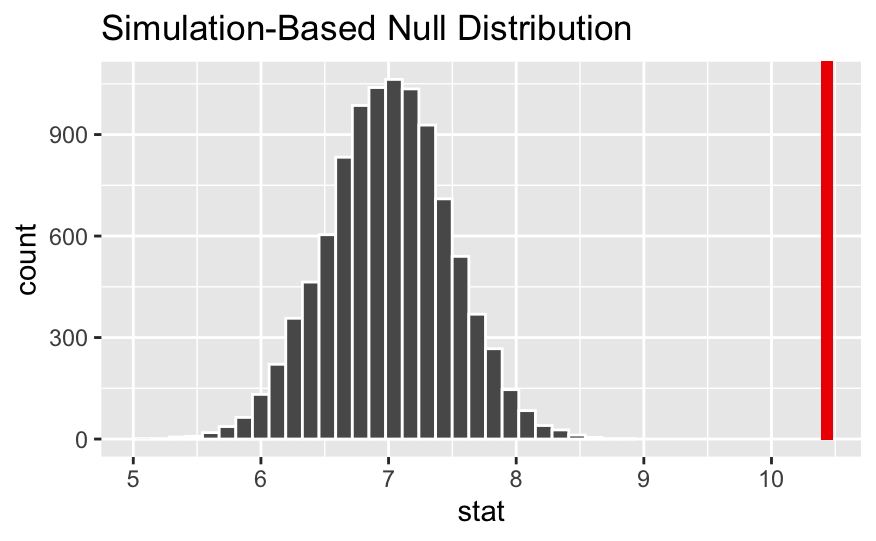

```r
null_distribution %>%
  visualise(bins = 30) +
  shade_p_value(obs_stat = observed_stat$average_sleep, direction = "both")
```

Calculating p-value

```r
p_value <- null_distribution %>%
  get_p_value(obs_stat = observed_stat$average_sleep, direction = "both")
p_value
```

| p_value |
| --- |
| 0 |

Here the p-value is 0, and so we reject H0 in favour of Ha. The current mean average_sleep for our imaginary Jabberwockies is 7, which is significantly different to the value 10.43373 average_sleep for our data set of animals.

TWO-SAMPLE HYPOTHESIS TESTS Perform an appropriate statistical test to determine whether omnivores sleep for significantly longer than herbivores, on average. Please note : Omnivours and Harbivours are 2 independent Samples

First, we’ll set the conventional significance level α=0.05 and write our hypotheses. This will be a one-tailed test:

H0: μsleep(Omnivores)−μsleep(Herbivores) = 0 Ha: μsleep(Omnivores)−μsleep(Herbivores) > 0

Let’s visualise the distributions and check the sizes of both samples.

```r
msleep %>%
  group_by(vore) %>%
  filter(str_detect(vore, "omni|herbi")) %>%
  summarise(n = n())
```

| vore | n |
| --- | --- |
| herbi | 32 |
| omni | 20 |

```r
NA
NA
```

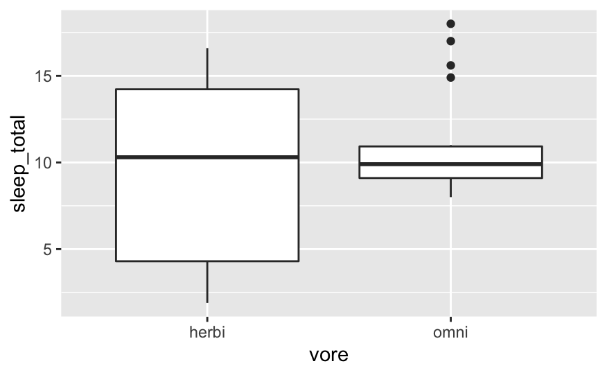

```r
msleep %>%
  filter(str_detect(vore, "omni|herbi")) %>%
  ggplot(aes(y = sleep_total, x = vore)) +
  geom_boxplot()
```

```r
null_distribution <- msleep %>%
  filter(str_detect(vore, "omni|herbi")) %>%
  specify(sleep_total ~ vore) %>%
  hypothesize(null = "independence") %>% #
  generate(reps = 1000, type = "permute") %>%
  calculate(stat = "diff in means", order = c("omni", "herbi"))

head(null_distribution)
```

| replicate | stat |
| --- | --- |
| 1 | -0.672500 |
| 2 | 1.098750 |
| 3 | 0.180625 |
| 4 | 1.813750 |
| 5 | -0.136250 |
| 6 | 0.099375 |

Let’s calculate our observed statistic and then visualise the null distribution and where the observed statistic lies on the distribution.

```r
observed_stat <- msleep %>%
  filter(str_detect(vore, "omni|herbi")) %>%
  specify(sleep_total ~ vore) %>%
  calculate(stat = "diff in means", order = c("omni", "herbi"))

observed_stat
```

| stat |
| --- |
| 1.415625 |

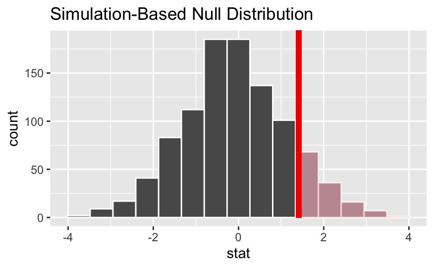

```r
null_distribution %>%
  visualise() +
  shade_p_value(obs_stat = observed_stat, direction = "right")
```

```r
p_value <- null_distribution %>%
  get_p_value(obs_stat = observed_stat, direction = "right")

p_value
```

| p_value |
| --- |
| 0.114 |

1.2 Hypothesis testing - interpretation

Q1. You work for a independent coffee shop. You’ve performed a small survey in the local town and found that 40% of the people you randomly asked were aware of your shop in the town. You then conduct a marketing campaign by flyering local venues and targeting advertisements on social media. Finally you conduct a second small random survey in the town, asking if people are aware of your coffee shop. You want to test the hypothesis that the campaign has significantly increased awareness of the shop.

Ans : This is a case where in comparison is between two Paired (aka dependent) samples

We are interested in finding out: ‘Is there a significant difference on percentage of people randomly surveyed who knew about the shop before the marketing campaing vs the percentage of people again randomly surveyed aware of the coffee shop after the marketing campaign?’

We’ll stick with the conventional significance level α=0.05 when answering this question.

One way we could address this is by adding a new column diff_new to the dataframe, which is the difference between the number of people who knew about the coffee shop before the campaign against the number of people who new about the coffee shop after the campaign.

H0 : μdiff_new=0 Ha: μdiff_new≠0

Significance level: 0.05, calculated p-value: 0.07

The p-value is grater than α=0.05, so we fail to reject H0 and conclude that, on average, the percentage of random people surveyed and knew about the coffee shop before the marketing campaign does not differ significantly in camparison the the percentage of people surveyed randomly and knew about the coffee shop after the marketing campaign. Hence we can conclude that the marketing campaign was not a great success.

Ans 2 .

This is a case where in comparison is between two Paired (aka dependent) samples

We are interested in finding out: ‘Is there a significant difference on proportion of people who click on the banner in its current position vs the proportion of people who click on the banner in its new position ?

We’ll stick with the conventional significance level α=0.05 when answering this question.

One way we could address this is by adding a new column diff_new to the dataframe, which is the difference between the proportion of people who click on the banner in its current position against the proportion of people who click on the banner in its new position.

H0 : μdiff_new=0 Ha: μdiff_new≠0

Significance level: 0.01, p-value: 0.006

Q3. You work as an analyst for a car manufacturing company - they have specific standards they must meet for standards and regulation purposes. You have been asked to check the quality control of the manufacture of a particular car part. The part must have a width of 145mm, with a small (given) level of tolerance. You have been given data on a sample of 1,000 parts produced over the period of a week.

Ans 3 This is an example of a one sample mean test

H0 : μaverage_rating = 145 Ha: μaverage_rating ≠ 145

We frame this question in terms of two competing hypotheses: H0: - the current mean average_rating is meeting the specified standards and regulations.

Ha: (the alternative hypothesis) - the current mean average_rating is not meeting the specified standards and regulations.

Significance level: 0.05, p-value: 0.55